# PROJECT REPORT

Yasemin Gokdag , Eda Yildiz, Emirhan Bugday

January 7, 2019

## DATA CLEANING

As we analyze the data, we realized that for there are some spelling differences for some teams in the dataset. These differences may not be so important for the reader but it make a big difference in coding because we do not have team Ids. For example, Manchester United is a very well-known team even among the people who are not a fan of football. The name of this team appears in 4 different spelling in the data set as follows:

- manchester-united
- manchester united
- manchester utd
- manchester-utd

This causes us to lose the previous match analysis data, which are very important for our newly extracted features and therefore prediction approach. In order not to lose any information, we first make the spelling correction in the team names. Details of the correction approach can be found in *Appendix*

## NEW FEATURE EXTRACTION

In addition to the odd features extracted in the base code, match performance related features are extracted at this phase.

It is important to analyze the previous match results played between the home and away teams in predicting the future matches. Number of goals scored by each team in the previous matches, overall result summary of the previous matches, score that is assigned to each team for its performance in the recent matches are the features extracted. The detailed explanation is as follows.

In order to clarify the identical and two-way home-away matches we can give the following example. For Arsenal & Wolves matching if Home = Arsenal and Away= Wolves identical matches are also Home = Arsenal and Away = Wolves matches. But the two-way home-away matches include matches for both Home = Arsenal and Away= Wolves or Home = Wolve and Away= Arsenal.

For each match the related feature (Home position feature for the Home team and Away position feature for the Away team) will be used.

4. FIFA Rating Differences

From the website (https://www.fifaindex.com) the FIFA Ratings at the beginning of the season are extracted. There are four different ratings for each team. Ratings are as follows: Attack, Defense, Midfield, Overall. We created 4 features by the following calculations :

- Attack Difference as (Home Attack - Away Attack)
- Midfield Difference as (Home Midfield -Away Midfield)
- Overall Difference as (Home Overall -Away Overall)
- Defense Difference as (Home Defense -Away Defense)

The detailed analysis can be seen from [1]

5. ELO Ratings

From the website (http://clubelo.com/ENG) the ELO Ratings are extracted for each team. Elo Ratings are used as an indicator of the performance for each team. As explained in [1], it is shown to perform well as a predictor.

## DATA PREPERATION

After feature extraction we end up with lots of features and most of them are correlated among each others. In order to prevent curse of dimensionality, PCA method is applied and we obtain 12 features that can explain almost %98 of the variance in the dataset. The related graphs can be seen from below:

```
## Number of bookmakers with proportion of missings below 0.01 since 2012-07-15 : 15
## Number of bookmakers with no missings since testStart 2019-01-01 : 15
```

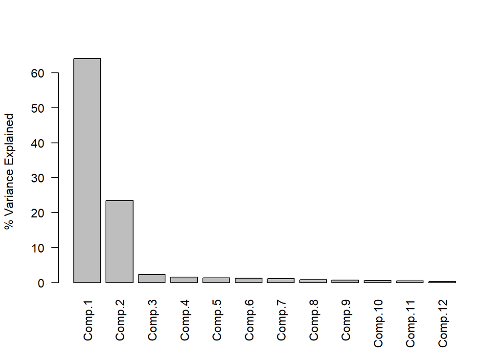

As seen on the graph, selected 12 components explain about 98% of the variation.

Even though the components seem to explain data very well, as we carry out our analysis, we noticed some problems regarding the usage of PCA. It is possible that treating low variance axes as noise deteriorate the performance of the prediction model since small differences has significant impact on the predicted probabilities.

Since we did not use it, we did not add our PCA function into main code segment. However, it can be found as a function in *Appendix*

After these analysis, we decided to use all the features that we obtained in prediction model.

## ALTERNATIVE MODELS

After obtaining the feature set we tried lots of model that is applicable for the data set.

- Penalized Regression
- Random Forest
- Gradient Boosting method

Round results are as follows :

```
##      matchId Match_Date            Home           Away rank Match_Result
##  1: CMONHwmi 2019-01-01         everton      leicester    3         Away
##  2: EXqAbGnT 2019-01-01         arsenal         fulham    1         Home
##  3: KEMxfzep 2019-01-02     bournemouth        watford    4          Tie
##  4: KhFrDF1M 2019-01-02          wolves crystal-palace    9         Away
##  5: YyDWFHH3 2019-01-03 manchester-city      liverpool   10         Home
##  6: b5LtgfAj 2019-01-02         chelsea    southampton    5          Tie
##  7: jDNRGc2c 2019-01-02    huddersfield        burnley    6         Away
##  8: nuHzFyX9 2019-01-02       newcastle manchester-utd    7         Away
##  9: t2GvEenG 2019-01-02        west-ham       brighton    8          Tie
## 10: tdZj1C33 2019-01-01         cardiff      tottenham    2         Away
## 11: CMONHwmi 2019-01-01         everton      leicester    3         Away
## 12: EXqAbGnT 2019-01-01         arsenal         fulham    1         Home
## 13: KEMxfzep 2019-01-02     bournemouth        watford    4          Tie
## 14: YyDWFHH3 2019-01-03 manchester-city      liverpool   10         Home
```

[output cut: 135 more lines]

RPS results for rounds are as follows :

```
##    Round       RPS
## 1:     1 0.1731728
## 2:     2 0.1740496
## 3:     3 0.1769088
## 4:     4 0.1765242
## 5:     5 0.1769975
## 6:     6 0.1731337
## 7:     7 0.1720778
## 8:     8 0.1927624
```

## Appendix

Data cleaning script :

```r
#' Data Preprocessing for Matches Data
#'
#' Makes preprocessing on raw matches data so that it can be used by other functions.
#'
#' @param data A data.table containing raw match data
#' @export
#' @examples
#' matches_data_preprocessing(matches_raw)
#'

matches_data_preprocessing <- function(data){

  temp = copy(data)
  temp = as.data.table(temp)
  temp = unique(temp,by="matchId")
  setnames(temp,c("home","away","score","date"),c("Home","Away","Score","Match_Date"))
  temp[,Home:=tolower(Home)]
  temp[,Away:=tolower(Away)]
  temp[,Match_DateTime:=as.POSIXct(Match_Date,tz="UTC",origin = as.POSIXct("1970-01-01",tz="UTC"))]
  temp[,Match_Hour := format(strptime(Match_DateTime,"%Y-%m-%d %H:%M:%OS"),'%H')]
  temp[,Match_Hour := as.numeric(Match_Hour)]
  temp[,Match_Date := as.Date(Match_DateTime,format="%Y-%m-%d")]

  temp[,AWA_FLAG:=0]
  temp[(Score %like% "AWA."),`:=`(Score=gsub("AWA.","",Score),AWA_FLAG=1)]
  temp[,POSTP_FLAG:=0]
  temp[(Score == "POSTP."),`:=`(Score=gsub("POSTP.","",Score),POSTP_FLAG=1)]
  temp[,CAN_FLAG:=0]
  temp[(Score == "CAN."),`:=`(Score=gsub("CAN.","",Score),CAN_FLAG=1)]
  latestDateTimeofKnownScore = max(temp[Score!=""]$Match_DateTime)
  POSTP_toberemoved = temp[which(temp$POSTP_FLAG==1 & temp$Match_DateTime <= latestDateTimeofKnownScore)]$matchId
  if(length(POSTP_toberemoved)!=0){
    cat("Following postponed matches are REMOVED during data_preprocessing:\n")
    print(data[matchId%in%POSTP_toberemoved,])
    temp=temp[!matchId%in%POSTP_toberemoved,]
  }
  POSTP_tobekept = temp[which(temp$POSTP_FLAG==1 & temp$Match_DateTime > latestDateTimeofKnownScore)]$matchId
  if(length(POSTP_tobekept)!=0){
    cat("Following postponed matches are KEPT during data_preprocessing:\n")
    print(data[matchId%in%POSTP_tobekept,])
  }

  temp[,c("Home_Score","Away_Score") := lapply(tstrsplit(Score,":",fixed=T),as.integer)]
  temp[,`:=`(Match_Result = ifelse(Home_Score == Away_Score, "Tie" , ifelse(Home_Score > Away_Score, 'Home' , 'Away'))
             ,Total_Score = Home_Score + Away_Score)]
  temp[,`:=`(Result_Home = ifelse(Match_Result=="Home",1,0)
             ,Result_Tie = ifelse(Match_Result=="Tie",1,0)
             ,Result_Away = ifelse(Match_Result=="Away",1,0))]

  temp[,c('Score','Match_DateTime','AWA_FLAG','POSTP_FLAG','CAN_FLAG'):=NULL]

  #standardize team names
  temp[, Home := gsub(" ","-",Home)]
  temp[, Away := gsub(" ","-",Away)]

  temp[, Home := gsub("utd","united",Home)]
  temp[, Away := gsub("utd","united",Away)]

  HomeTeams <- as.data.table(unique(temp$Home))
  AwayTeams <- as.data.table(unique(temp$Away))

  teamnames_split <- unique(rbind(HomeTeams[,1],AwayTeams[,1]))
  setnames(teamnames_split, "Name")

  teamnames_split <- teamnames_split[, c("Pre","Suf") := tstrsplit(Name, "-", fixed=TRUE)]
  teamnames <- unique(rbind(as.data.table(teamnames_split$Name), as.data.table(teamnames_split$Pre)))
  setnames(teamnames,"Name")

  teamnames <- teamnames[, c("Pre","Suf") := tstrsplit(Name, "-", fixed=TRUE)]
  unique_count <- teamnames[,.(Count = length(unique(Suf))),by=Pre]

  teamnames_split[ is.na(Suf), Suf := "" ]
  teamnames_split <- merge(teamnames_split, unique_count, by.x = "Pre" , by.y = "Pre")

  teamnames_split[Count == 3, NewName := paste0(Pre, "-", Suf)]
  teamnames_split[Count <  3, NewName := Pre]

  teamnames_split[, c("Pre","Suf","Count") := NULL]

  setkey(temp, Home)
  setkey(teamnames_split, Name)
  temp[teamnames_split, Home := NewName]

  setkey(temp, Away)
  setkey(teamnames_split, Name)
  temp[teamnames_split, Away := NewName]

  gc()
  return(temp)
}

#' Data Preprocessing for Odd Details Data
#'
#' Makes preprocessing on raw odd details data so that it can be used by other functions.
#' only 1x2 bets are considered, if you are interested in other type of odds manipulate ''which_bets''
#' @param data A data.table containing raw odd details data
#' @param remove_bookmaker A character vector containing the bookmakers to be removed
#' @export
#' @examples

details_data_preprocessing <- function(data,matches,which_bets=c('1x2'),remove_bookmaker=c('BetfairExchange','PaddyPower'),removeOlderThan=30){
  # data manipulation for historical odd data
  details = copy(data)

  #remove duplicate entries
  details = unique(details)

  details = details[betType %in% which_bets]
  details[,totalhandicap:=NULL]

  details = merge(details,matches[,list(matchId,Match_Date)],by="matchId",all.x=T)
  setnames(details,"date","OddChangeDateTime")
  details[,OddChangeDateTime:=as.POSIXct(OddChangeDateTime,tz="UTC",origin = as.POSIXct("1970-01-01",tz="UTC"))]
  details = details[difftime(Match_Date,OddChangeDateTime, units = "days") <= removeOlderThan] #remove odds seen earlier than 10 days from the match date
  details[, odd := as.numeric(odd)]

  details[,bookmaker:=gsub(" |-","",bookmaker)]
  if(!is.null(remove_bookmaker)){
    details = details[!(bookmaker %in% remove_bookmaker)]
  }

  gc()
  return(details)
}


getmode <- function(v)
{
  uniqv <- unique(v)
  uniqv[which.max(tabulate(match(v, uniqv)))]
}
```

Data preprocessing script :

```r
#' Data Preprocessing for Matches Data
#'
#' Makes preprocessing on raw matches data so that it can be used by other functions.
#'
#' @param data A data.table containing raw match data
#' @export
#' @examples
#' matches_data_preprocessing(matches_raw)
#'

matches_data_preprocessing <- function(data){

  temp = copy(data)
  temp = unique(temp,by="matchId")
  setnames(temp,c("home","away","score","date"),c("Home","Away","Score","Match_Date"))
  temp[,Home:=tolower(Home)]
  temp[,Away:=tolower(Away)]
  temp[,Match_DateTime:=as.POSIXct(Match_Date,tz="UTC",origin = as.POSIXct("1970-01-01",tz="UTC"))]
  temp[,Match_Hour := format(strptime(Match_DateTime,"%Y-%m-%d %H:%M:%OS"),'%H')]
  temp[,Match_Hour := as.numeric(Match_Hour)]
  temp[,Match_Date := as.Date(Match_DateTime,format="%Y-%m-%d")]

  temp[,AWA_FLAG:=0]
  temp[(Score %like% "AWA."),`:=`(Score=gsub("AWA.","",Score),AWA_FLAG=1)]
  temp[,POSTP_FLAG:=0]
  temp[(Score == "POSTP."),`:=`(Score=gsub("POSTP.","",Score),POSTP_FLAG=1)]
  temp[,CAN_FLAG:=0]
  temp[(Score == "CAN."),`:=`(Score=gsub("CAN.","",Score),CAN_FLAG=1)]
  latestDateTimeofKnownScore = max(temp[Score!=""]$Match_DateTime)
  POSTP_toberemoved = temp[which(temp$POSTP_FLAG==1 & temp$Match_DateTime <= latestDateTimeofKnownScore)]$matchId
  if(length(POSTP_toberemoved)!=0){
    cat("Following postponed matches are REMOVED during data_preprocessing:\n")
    print(data[matchId%in%POSTP_toberemoved,])
    temp=temp[!matchId%in%POSTP_toberemoved,]
  }
  POSTP_tobekept = temp[which(temp$POSTP_FLAG==1 & temp$Match_DateTime > latestDateTimeofKnownScore)]$matchId
  if(length(POSTP_tobekept)!=0){
    cat("Following postponed matches are KEPT during data_preprocessing:\n")
    print(data[matchId%in%POSTP_tobekept,])
  }

  temp[,c("Home_Score","Away_Score") := lapply(tstrsplit(Score,":",fixed=T),as.integer)]
  temp[,`:=`(Match_Result = ifelse(Home_Score == Away_Score, "Tie" , ifelse(Home_Score > Away_Score, 'Home' , 'Away'))
             ,Total_Score = Home_Score + Away_Score)]
  temp[,`:=`(Result_Home = ifelse(Match_Result=="Home",1,0)
             ,Result_Tie = ifelse(Match_Result=="Tie",1,0)
             ,Result_Away = ifelse(Match_Result=="Away",1,0))]

  temp[,c('Score','Match_DateTime','AWA_FLAG','POSTP_FLAG','CAN_FLAG'):=NULL]
  gc()
  return(temp)
}

#' Data Preprocessing for Odd Details Data
#'
#' Makes preprocessing on raw odd details data so that it can be used by other functions.
#' only 1x2 bets are considered, if you are interested in other type of odds manipulate ''which_bets''
#' @param data A data.table containing raw odd details data
#' @param remove_bookmaker A character vector containing the bookmakers to be removed
#' @export
#' @examples

details_data_preprocessing <- function(data,matches,which_bets=c('1x2'),remove_bookmaker=c('BetfairExchange','PaddyPower'),removeOlderThan=30){
  # data manipulation for historical odd data
  details = copy(data)

  #remove duplicate entries
  details = unique(details)

  details = details[betType %in% which_bets]
  details[,totalhandicap:=NULL]

  details = merge(details,matches[,list(matchId,Match_Date)],by="matchId",all.x=T)
  setnames(details,"date","OddChangeDateTime")
  details[,OddChangeDateTime:=as.POSIXct(OddChangeDateTime,tz="UTC",origin = as.POSIXct("1970-01-01",tz="UTC"))]
  details = details[difftime(Match_Date,OddChangeDateTime, units = "days") <= removeOlderThan] #remove odds seen earlier than 10 days from the match date
  details[, odd := as.numeric(odd)]

  details[,bookmaker:=gsub(" |-","",bookmaker)]
  if(!is.null(remove_bookmaker)){
    details = details[!(bookmaker %in% remove_bookmaker)]
  }

  gc()
  return(details)
}




getmode <- function(v) {
  uniqv <- unique(v)
  uniqv[which.max(tabulate(match(v, uniqv)))]
}



extract_features.PreviousResults<- function(matches,teststart){

  matches=matches[Match_Date<teststart]

  DistinctSides= unique(matches[,c('Home','Away'),with=F])
  DistinctSides[,rowcount:=1:.N]

  DistinctSides[,TeamsId:=0]
  for (i in 1:nrow(DistinctSides))
  {
    DistinctSides[( TeamsId==0 & rowcount==i )| (rowcount>i & Home==DistinctSides[i]$Away & Away==DistinctSides[i]$Home), TeamsId:=i]
  }

  setnames(DistinctSides,'rowcount','Identical')
  setkey(DistinctSides,Home,Away)
  setkey(matches,Home,Away)

  matches=DistinctSides[matches]

  matches[,Winner:=ifelse(Match_Result=='Home',Home,'Else')]
  matches[Winner=='Else',Winner:=ifelse(Match_Result=='Away',Away,'Tie')]

  PreviousMatches=matches[,c('Match_Date','matchId','Winner','Home','Away','TeamsId'),with=F]


  PreviousMatches[order(Match_Date),Identical1:=shift(Winner,1,type='lag'),by=c('Home','Away') ]
  PreviousMatches[order(Match_Date),Identical2:=shift(Winner,2,type='lag'),by=c('Home','Away') ]
  PreviousMatches[order(Match_Date),Identical3:=shift(Winner,3,type='lag'),by=c('Home','Away') ]
  PreviousMatches[order(Match_Date),Identical4:=shift(Winner,4,type='lag'),by=c('Home','Away') ]
  PreviousMatches[order(Match_Date),Identical5:=shift(Winner,5,type='lag'),by=c('Home','Away') ]
  PreviousMatches[order(Match_Date),Identical5:=shift(Winner,5,type='lag'),by=c('Home','Away') ]

  PreviousMatches[order(Match_Date),TwoWay1:=shift(Winner,1,type='lag'),by=TeamsId ]
  PreviousMatches[order(Match_Date),TwoWay2:=shift(Winner,2,type='lag'),by=TeamsId ]
  PreviousMatches[order(Match_Date),TwoWay3:=shift(Winner,3,type='lag'),by=TeamsId ]
  PreviousMatches[order(Match_Date),TwoWay4:=shift(Winner,4,type='lag'),by=TeamsId ]
  PreviousMatches[order(Match_Date),TwoWay5:=shift(Winner,5,type='lag'),by=TeamsId ]

  PreviousMatches$Identical5Freq=apply(PreviousMatches[,c('Identical1','Identical2','Identical3','Identical4','Identical5'),with=F],1,getmode)
  PreviousMatches$TwoWay5Freq=apply(PreviousMatches[,c('TwoWay1','TwoWay2','TwoWay3','TwoWay4','TwoWay5'),with=F],1,getmode)

  PreviousMatches$Identical2Freq=apply(PreviousMatches[,c('Identical1','Identical2'),with=F],1,getmode)
  PreviousMatches$TwoWay2Freq=apply(PreviousMatches[,c('TwoWay1','TwoWay2'),with=F],1,getmode)

  PreviousMatches$Identical1Freq=apply(PreviousMatches[,c('Identical1'),with=F],1,getmode)
  PreviousMatches$TwoWay1Freq=apply(PreviousMatches[,c('TwoWay1'),with=F],1,getmode)


  PreviousMatches=PreviousMatches[,c('matchId','Identical5Freq','TwoWay5Freq','Identical2Freq','TwoWay2Freq','Identical1Freq','TwoWay1Freq'),with=F]
  return(PreviousMatches)

}
```

Feature extraction script & PCA function

```r
#' Feature Extraction

extract_features.openclose <- function(matches,odd_details,pMissThreshold=0.01,trainStart,testStart){

  details = copy(odd_details)
  matches = copy(matches)

  details=details[order(OddChangeDateTime)]
  feature_odd_details=details[,list(Odd_Open=odd[1],Odd_Close=odd[.N]),list(matchId,betType,oddtype,bookmaker)]

  feature_odd_details = merge(matches[,list(matchId,Match_Date)], feature_odd_details,by="matchId")


  #HANDLE MISSINGS
  details_temp = dcast(feature_odd_details, matchId+betType ~ paste0("Odd_Close_",bookmaker)+oddtype, value.var = c("Odd_Close"))
  details_melt = melt(details_temp, id.vars = c("matchId","betType"), measure.vars = names(details_temp)[names(details_temp) %like% "Odd_Close"], value.name = "odd")
  details_melt[,c("OpenClose","bookmaker","oddtype"):=tstrsplit(variable,split="_",keep=c(2:4))]
  details_melt[,variable:=NULL]
  details_melt = merge(matches[,list(matchId,Match_Date)], details_melt,by="matchId",all=T)

  bookieMissingness = details_melt[Match_Date >= trainStart,list(.N,percMiss=sum(is.na(odd))/.N),by=list(bookmaker,betType)]
  bookiesToKeep = unique(bookieMissingness[percMiss <= pMissThreshold]$bookmaker)
  cat("Number of bookmakers with proportion of missings below",pMissThreshold,"since",as.character(trainStart),":",length(bookiesToKeep),"\n")

  nonmissingBookmakers_sinceTestStart = unique(details_melt[Match_Date >= testStart, list(.N,NA_SUM=sum(is.na(odd))),by=list(bookmaker,betType)][NA_SUM==0]$bookmaker)
  bookiesToKeep = intersect(bookiesToKeep,nonmissingBookmakers_sinceTestStart)
  cat("Number of bookmakers with no missings since testStart", as.character(testStart), ":", length(bookiesToKeep), "\n")

  details = dcast(feature_odd_details,matchId~oddtype+bookmaker,value.var = c("Odd_Open","Odd_Close"))
  columnsToKeep = grep(paste(bookiesToKeep,collapse="|"),names(details),value=T)
  details = details[,c('matchId',columnsToKeep),with=F]
  #HANDLE MISSINGS END


  details = merge(matches[,-c('Home','Away','Home_Score','Away_Score','Total_Score','Result_Home','Result_Tie','Result_Away','type'),with=F],
                  details,by="matchId",all=T)


  return(features = details)
}



getmode <- function(v) {
  uniqv <- unique(v)
  uniqv[which.max(tabulate(match(v, uniqv)))]
}



extract_features.PreviousResults<- function(matches){


  DistinctSides= unique(matches[,c('Home','Away'),with=F])
  DistinctSides[,rowcount:=1:.N]

  DistinctSides[,TeamsId:=0]
  for (i in 1:nrow(DistinctSides))
  {
    DistinctSides[( TeamsId==0 & rowcount==i )| (rowcount>i & Home==DistinctSides[i]$Away & Away==DistinctSides[i]$Home), TeamsId:=i]
  }

  setnames(DistinctSides,'rowcount','Identical')
  setkey(DistinctSides,Home,Away)
  setkey(matches,Home,Away)

  matches=DistinctSides[matches]

  matches[,Winner:=ifelse(Match_Result=='Home',Home,'Else')]
  matches[Winner=='Else',Winner:=ifelse(Match_Result=='Away',Away,'Tie')]

  PreviousMatches=matches[,c('Match_Date','matchId','Winner','Home','Away','TeamsId'),with=F]

  PreviousMatches[order(Match_Date),Identical1:=shift(Winner,1,type='lag'),by=c('Home','Away') ]
  PreviousMatches[order(Match_Date),Identical2:=shift(Winner,2,type='lag'),by=c('Home','Away') ]
  PreviousMatches[order(Match_Date),Identical3:=shift(Winner,3,type='lag'),by=c('Home','Away') ]
  PreviousMatches[order(Match_Date),Identical4:=shift(Winner,4,type='lag'),by=c('Home','Away') ]
  PreviousMatches[order(Match_Date),Identical5:=shift(Winner,5,type='lag'),by=c('Home','Away') ]
  PreviousMatches[order(Match_Date),Identical5:=shift(Winner,5,type='lag'),by=c('Home','Away') ]

  PreviousMatches[order(Match_Date),TwoWay1:=shift(Winner,1,type='lag'),by=TeamsId ]
  PreviousMatches[order(Match_Date),TwoWay2:=shift(Winner,2,type='lag'),by=TeamsId ]
  PreviousMatches[order(Match_Date),TwoWay3:=shift(Winner,3,type='lag'),by=TeamsId ]
  PreviousMatches[order(Match_Date),TwoWay4:=shift(Winner,4,type='lag'),by=TeamsId ]
  PreviousMatches[order(Match_Date),TwoWay5:=shift(Winner,5,type='lag'),by=TeamsId ]

  # PreviousMatches$Identical5Freq=apply(PreviousMatches[,c('Identical1','Identical2','Identical3','Identical4','Identical5'),with=F],1,getmode)
  # PreviousMatches$TwoWay5Freq=apply(PreviousMatches[,c('TwoWay1','TwoWay2','TwoWay3','TwoWay4','TwoWay5'),with=F],1,getmode)

  PreviousMatches$Identical2Freq=apply(PreviousMatches[,c('Identical1','Identical2'),with=F],1,getmode)
  PreviousMatches$TwoWay2Freq=apply(PreviousMatches[,c('TwoWay1','TwoWay2'),with=F],1,getmode)

  PreviousMatches$Identical1Freq=apply(PreviousMatches[,c('Identical1'),with=F],1,getmode)
  PreviousMatches$TwoWay1Freq=apply(PreviousMatches[,c('TwoWay1'),with=F],1,getmode)


  PreviousMatches=PreviousMatches[,c('matchId','Identical2Freq','TwoWay2Freq','Identical1Freq','TwoWay1Freq'),with=F]
  return(PreviousMatches)

}

extract_features.HomeAwayPerformances<- function(matches,nmatch = 5){

data= matches
#Get mode(result) of the previous 10 games per home per game
data <- data[order(Home, -Match_Date)][, HomeMatchRank := 1:.N, list(Home)]
Bound <- max(data$HomeMatchRank)

HomeResults <- data.table()
for (i in (1:Bound))
{
  matchIds=data[HomeMatchRank==i]$matchId
  select_data <- data[HomeMatchRank > i & HomeMatchRank <= i+nmatch][, list(lapply(Match_Result,getmode)), by = c("Home")]
  if (nrow(select_data) >0) {
  colnames=colnames(select_data)
  select_data <-as.data.table(matrix(unlist(select_data), nrow=nrow(select_data)),stringsAsFactors=FALSE)
  setnames(select_data,colnames)
  select_data <- select_data[, (lapply(.SD,getmode)), by = c("Home")]
  select_data=cbind(select_data,matchIds)
  HomeResults <- rbind(HomeResults,select_data)
 }
}

setnames(HomeResults,'V1','HomeResult')

data <- data[order(Away, -Match_Date)][, AwayMatchRank := 1:.N, list(Away)]
Bound <- max(data$AwayMatchRank)

AwayResults <- data.table()
for (i in (1:Bound))
{

  matchIds=data[AwayMatchRank==i]$matchId
  select_data <- data[AwayMatchRank > i & AwayMatchRank <= i+nmatch][, list(lapply(Match_Result,getmode)), by = c("Away")]
  if (nrow(select_data) >0) {
  colnames=colnames(select_data)
  select_data <-as.data.table(matrix(unlist(select_data), nrow=nrow(select_data)),stringsAsFactors=FALSE)
  setnames(select_data,colnames)
  select_data <- select_data[, (lapply(.SD,getmode)), by = c("Away")]
  select_data=cbind(select_data,matchIds)
  AwayResults <- rbind(AwayResults,select_data)
  }
}
```

```r
setnames(AwayResults,'V1','AwayResult')

setkey(AwayResults,matchIds)
setkey(HomeResults,matchIds)

Results=AwayResults[HomeResults]

return(Results)
}


extract_features.ELORatings <- function(){

  # read data
  ELORatings=fread("Elo_Ratings.txt")
  return(ELORatings)
}

extract_features.GoalDifferences<- function(matches){

  Teams =as.data.table(unique(matches$Home))
  Teams2 =as.data.table(unique(matches$Away) )
  Teams=unique(rbind(Teams,Teams2))


  Goal_v=data.table()
  Goal_va=data.table()

  for (i in 1:nrow(Teams))
  {
    Team = Teams[i]
    PreviousMatches=matches[Home==Team$V1 | Away==Team$V1][order(Match_Date)]
    PreviousMatches[Home==Team$V1,GolFor := Home_Score]
    PreviousMatches[Away==Team$V1,GolFor := Away_Score]
    PreviousMatches[Away==Team$V1,GolAgainst := Home_Score]
    PreviousMatches[Home==Team$V1,GolAgainst := Away_Score]

    PreviousMatches[order(Match_Date),GoalDif:=( shift(GolFor,1,type='lag')-shift(GolAgainst,1,type='lag')+
                                                   shift(GolFor,2,type='lag')-shift(GolAgainst,2,type='lag')+
                                                   shift(GolFor,3,type='lag')-shift(GolAgainst,3,type='lag')+                                    +
                                                   shift(GolFor,4,type='lag')-shift(GolAgainst,4,type='lag')+
                                                   shift(GolFor,5,type='lag')-shift(GolAgainst,5,type='lag')+
                                                   shift(GolFor,6,type='lag')-shift(GolAgainst,6,type='lag')) ]

    Goal=PreviousMatches[Home==Team$V1,c('matchId','GoalDif'),with=F]
    GoalA=PreviousMatches[Away==Team$V1,c('matchId','GoalDif'),with=F]
    setnames(Goal,'GoalDif','HomeGoalDif')
    setnames(GoalA,'GoalDif','AwayGoalDif')
    Goal_v=rbind(Goal_v,Goal)
    Goal_va=rbind(Goal_va,GoalA)
  }

  setkey(Goal_v,matchId)
  setkey(Goal_va,matchId)
  GoalDifferences=Goal_va[Goal_v]
  GoalDifferences[,DifferenceinGoalDif:=HomeGoalDif-AwayGoalDif]
  GoalDifferences=GoalDifferences[,c(1,4),with=F]
  return(GoalDifferences)


}


extract_features.FIFARatings <- function(matches){

  # read data
  FifaRatings=fread("Fifa_Rating.txt")

  Teams=unique(matches[,c('Home','Away'),with=F])

  setkey(Teams,Home)
  setkey(FifaRatings,Team)
  Teams=FifaRatings[Teams]

  setnames(Teams,c(2:5),c('HomeAttack','HomeMidfield','HomeDefense','HomeOverall'))

  setkey(Teams,Away)
  setkey(FifaRatings,Team)
  Teams=FifaRatings[Teams]

  setnames(Teams,c('Attack','Midfield','Defense','Overall'),c('AwayAttack','AwayMidfield','AwayDefense','AwayOverall'))
  setnames(Teams,'Team','Home')
  setnames(Teams,'i.Team','Away')


  Teams=Teams[,list(AttackDiff=HomeAttack-AwayAttack,
              MidfieldDiff=HomeMidfield-AwayMidfield,
              DefenseDiff=HomeDefense-AwayDefense,
              OverallDiff=HomeOverall-AwayOverall),list(Home,Away)]

  MatchIds=matches[,c('matchId','Home','Away'),with=FALSE]

  setkey(MatchIds,Home,Away)
  setkey(Teams,Home,Away)
  FifaRatingDiff=Teams[MatchIds]
  return(FifaRatingDiff)

}


extract_features.CombineFeatures <- function(matches,odd_details,pMissThreshold=0.01,trainStart,testStart){

  OddFeatures=extract_features.openclose(matches,odd_details,pMissThreshold=0.01,trainStart,testStart)

  setkey(OddFeatures,matchId)

  FifaRatingDiff=extract_features.FIFARatings(matches)
  ELO=extract_features.ELORatings()
  HomeAwayRecentPerf=  extract_features.HomeAwayPerformances(matches,nmatch=10)
  PreviousResults=extract_features.PreviousResults(matches)


  MatchIds=matches[,c('matchId','Home','Away'),with=FALSE]
  setkey(MatchIds,Home)
  setkey(ELO,Team)
  Data=ELO[MatchIds]
  setnames(Data,'ELO','HomeELO')
  setnames(Data,'Team','Home')
  setkey(Data,Away)
  setkey(ELO,Team)
  Data=ELO[Data]
  setnames(Data,'ELO','AwayELO')
  setnames(Data,'Team','Away')

  FifaRatingDiff$Home=NULL
  FifaRatingDiff$Away=NULL
  HomeAwayRecentPerf$Away=NULL
  HomeAwayRecentPerf$Home=NULL


  setkey(Data,matchId)
  setkey(FifaRatingDiff,matchId)
  Data=FifaRatingDiff[Data]


  setkey(Data,matchId)
  setkey(HomeAwayRecentPerf,matchIds)
  Data=HomeAwayRecentPerf[Data]

  setkey(Data,matchIds)
  setkey(PreviousResults,matchId)
  Data=PreviousResults[Data]

  # Data[Identical5Freq==Away,Identical5Freq:=2]
  # Data[Identical5Freq==Home,Identical5Freq:=1]
  # Data[Identical5Freq=='Tie',Identical5Freq:=0]
  # Data[TwoWay5Freq==Away,TwoWay5Freq:=2]
  # Data[TwoWay5Freq==Home,TwoWay5Freq:=1]
  # Data[TwoWay5Freq=='Tie',TwoWay5Freq:=0]
  Data[Identical2Freq==Away,Identical2Freq:=2]
  Data[Identical2Freq==Home,Identical2Freq:=1]
  Data[Identical2Freq=='Tie',Identical2Freq:=0]

  Data$Identical2Freq <- as.numeric(Data$Identical2Freq)

  Data[TwoWay2Freq==Away,TwoWay2Freq:=2]
  Data[TwoWay2Freq==Home,TwoWay2Freq:=1]
  Data[TwoWay2Freq=='Tie',TwoWay2Freq:=0]

  Data$TwoWay2Freq <- as.numeric(Data$TwoWay2Freq)


  Data[Identical1Freq==Away,Identical1Freq:=2]
  Data[Identical1Freq==Home,Identical1Freq:=1]
  Data[Identical1Freq=='Tie',Identical1Freq:=0]

  Data$Identical1Freq <- as.numeric(Data$Identical1Freq)

  Data[TwoWay1Freq==Away,TwoWay1Freq:=2]
  Data[TwoWay1Freq==Home,TwoWay1Freq:=1]
  Data[TwoWay1Freq=='Tie',TwoWay1Freq:=0]

  Data$TwoWay1Freq <- as.numeric(Data$TwoWay1Freq)

  Data[AwayResult=='Home',AwayResult:=1]
  Data[AwayResult=='Away',AwayResult:=2]
  Data[AwayResult=='Tie',AwayResult:=0]

  Data$AwayResult <- as.numeric(Data$AwayResult)

  Data[HomeResult=='Home',HomeResult:=1]
  Data[HomeResult=='Away',HomeResult:=2]
  Data[HomeResult=='Tie',HomeResult:=0]

  Data$HomeResult <- as.numeric(Data$HomeResult)

  Data[Identical1Freq=='Tie',Identical1Freq:=0]

  Data$Identical1Freq <- as.numeric(Data$Identical1Freq)

  setkey(Data,matchId)
  setkey(OddFeatures,matchId)
  Data=Data[OddFeatures]
  Data$Away=NULL
  Data$Home=NULL

  GoalDiff=  extract_features.GoalDifferences(matches)
  setkey(GoalDiff,matchId)
  setkey(Data,matchId)
  Data=GoalDiff [Data]

  setcolorder(Data, c("leagueId","Match_Date","Match_Hour","Match_Result","matchId","DifferenceinGoalDif","Identical2Freq","TwoWay2Freq","Identical1Freq","TwoWay1Freq","AwayResult","HomeResult","AttackDiff","MidfieldDiff","DefenseDiff","OverallDiff","AwayELO","HomeELO","Odd_Open_odd1_10Bet","Odd_Open_odd1_12BET","Odd_Open_odd1_188BET","Odd_Open_odd1_BetVictor","Odd_Open_odd1_Betclic","Odd_Open_odd1_Betsafe","Odd_Open_odd1_Betsson","Odd_Open_odd1_Betway","Odd_Open_odd1_Pinnacle","Odd_Open_odd1_SBOBET","Odd_Open_odd1_Unibet","Odd_Open_odd1_WilliamHill","Odd_Open_odd1_bet365","Odd_Open_odd1_betathome","Odd_Open_odd1_bwin","Odd_Open_odd2_10Bet","Odd_Open_odd2_12BET","Odd_Open_odd2_188BET","Odd_Open_odd2_BetVictor","Odd_Open_odd2_Betclic","Odd_Open_odd2_Betsafe","Odd_Open_odd2_Betsson","Odd_Open_odd2_Betway","Odd_Open_odd2_Pinnacle","Odd_Open_odd2_SBOBET","Odd_Open_odd2_Unibet","Odd_Open_odd2_WilliamHill","Odd_Open_odd2_bet365","Odd_Open_odd2_betathome","Odd_Open_odd2_bwin","Odd_Open_oddX_10Bet","Odd_Open_oddX_12BET","Odd_Open_oddX_188BET","Odd_Open_oddX_BetVictor","Odd_Open_oddX_Betclic","Odd_Open_oddX_Betsafe","Odd_Open_oddX_Betsson","Odd_Open_oddX_Betway","Odd_Open_oddX_Pinnacle","Odd_Open_oddX_SBOBET","Odd_Open_oddX_Unibet","Odd_Open_oddX_WilliamHill","Odd_Open_oddX_bet365","Odd_Open_oddX_betathome","Odd_Open_oddX_bwin","Odd_Close_odd1_10Bet","Odd_Close_odd1_12BET","Odd_Close_odd1_188BET","Odd_Close_odd1_BetVictor","Odd_Close_odd1_Betclic","Odd_Close_odd1_Betsafe","Odd_Close_odd1_Betsson","Odd_Close_odd1_Betway","Odd_Close_odd1_Pinnacle","Odd_Close_odd1_SBOBET","Odd_Close_odd1_Unibet","Odd_Close_odd1_WilliamHill","Odd_Close_odd1_bet365","Odd_Close_odd1_betathome","Odd_Close_odd1_bwin","Odd_Close_odd2_10Bet","Odd_Close_odd2_12BET","Odd_Close_odd2_188BET","Odd_Close_odd2_BetVictor","Odd_Close_odd2_Betclic","Odd_Close_odd2_Betsafe","Odd_Close_odd2_Betsson","Odd_Close_odd2_Betway","Odd_Close_odd2_Pinnacle","Odd_Close_odd2_SBOBET","Odd_Close_odd2_Unibet","Odd_Close_odd2_WilliamHill","Odd_Close_odd2_bet365","Odd_Close_odd2_betathome","Odd_Close_odd2_bwin","Odd_Close_oddX_10Bet","Odd_Close_oddX_12BET","Odd_Close_oddX_188BET","Odd_Close_oddX_BetVictor","Odd_Close_oddX_Betclic","Odd_Close_oddX_Betsafe","Odd_Close_oddX_Betsson","Odd_Close_oddX_Betway","Odd_Close_oddX_Pinnacle","Odd_Close_oddX_SBOBET","Odd_Close_oddX_Unibet","Odd_Close_oddX_WilliamHill","Odd_Close_oddX_bet365","Odd_Close_oddX_betathome","Odd_Close_oddX_bwin"))
  setnames(Data, "DifferenceinGoalDif", "GoalDiff")
```

```r
  return(as.data.table(Data))

}

extract_features.pcaComponents <- function(train_features, test_features){

  data <- train_features
  data <- na.omit(data)
  col <- ncol(data)
  row <- nrow(data)
  scaled_data <- data.table()
  data<- as.data.table(data)
  scaled_data <- rbind(scaled_data,features[,1:5])
  colnames <- names(data)

  for (j in 6:col)
  {
    scaled_data <- cbind(scaled_data, scale(data[,get(colnames[j])]))
    j = j+1
  }
  setnames(scaled_data, colnames)
  pca_prin <- princomp(scaled_data[,6:ncol(scaled_data)])
  load <- pca_prin$loadings
  load <- load[,1:12]
  load <- as.matrix(load)

  scaled_test <- data.table()
  scaled_test <- rbind(scaled_test,test_features[,1:5])
  for (j in 6:col)
  {
    scaled_test <- cbind(scaled_test, scale(test_features[,get(colnames[j])]))
    j = j+1
  }
  setnames(scaled_test, colnames)

  s <- scaled_test[,1:5]
  t <- scaled_test[,6:ncol(scaled_test)]
  t <- as.matrix(t)

  r <- t%*%load
  new_data_test <- cbind(s,r)

  s_2 <- scaled_data[,1:5]
  t_2 <- scaled_data[,6:ncol(scaled_data)]
  t_2 <- as.matrix(t)

  r_2 <- t_2%*%load
  new_data_train <- cbind(s_2,r_2)


  loadings = pca_prin$loadings[]
  p.variance.explained = pca_prin$sdev^2 / sum(pca_prin$sdev^2)

  # plot percentage of variance explained for each principal component
  p.plot <- barplot(100*p.variance.explained[1:12], las=2, xlab='', ylab='% Variance Explained')

  return(list(p.plot, new_data_test, new_data_train))
}
```

Performance metrics script :

```r
#' Performance Metric: Ranked Probability Score
#'
#' @param probs vector of 3, predicted probabilities
#' @param outcomes vector of 3, binary outcomes, should be provided with the same order as probs
#' @export
#' @examples
RPS_single<- function(probs,outcomes){
  probs = cumsum(probs)
  outcomes = cumsum(outcomes)
  RPS = sum((probs-outcomes )^2) / (length(probs)-1)
  return(RPS)
}

RPS_matrix<- function(probs,outcomes){
  probs=as.matrix(probs)
  outcomes=as.matrix(outcomes)
  probs=t(apply(t(probs), 2, cumsum))
  outcomes=t(apply(t(outcomes), 2, cumsum))
  RPS = apply((probs-outcomes)^2,1,sum) / (ncol(probs)-1)
  return(RPS)
}
```

Model training script :

```r
train_glmnet <- function(train_features, test_features,not_included_feature_indices=c(1:5), alpha=1,nlambda=50, tune_lambda=TRUE,nofReplications=5,nFolds=10,trace=T){

    set.seed(1)

    # glmnet works with complete data
    glm_features=train_features[complete.cases(train_features)]
    train_class=glm_features$Match_Result
    glm_train_data=glm_features[,-not_included_feature_indices,with=F]
    glm_test_data=test_features[,-not_included_feature_indices,with=F]
    if(tune_lambda){
        # to set lambda parameter, cross-validation will be performed and lambda is selected based on RPS performance

        cvindices=generateCVRuns(train_class,nofReplications,nFolds,stratified=TRUE)

        # first get lambda sequence for all data
        glmnet_alldata = glmnet(as.matrix(glm_train_data), as.factor(train_class), family="multinomial", alpha = alpha, nlambda=nlambda)
        lambda_sequence = glmnet_alldata$lambda

        cvresult=vector('list',nofReplications*nFolds)
        iter=1
        for(i in 1:nofReplications) {
            thisReplication=cvindices[[i]]
            for(j in 1:nFolds){
                if(trace){
                    cat(sprintf('Iteration %d: Fold %d of Replication %d\n',iter,j,i))
                }
                testindices=order(thisReplication[[j]])

                cvtrain=glm_train_data[-testindices]
                cvtrainclass=train_class[-testindices]
                cvtest=glm_train_data[testindices]
                cvtestclass=train_class[testindices]

                inner_cv_glmnet_fit = glmnet(as.matrix(cvtrain),as.factor(cvtrainclass),family="multinomial", alpha = alpha,lambda=lambda_sequence)
                valid_pred = predict(inner_cv_glmnet_fit, as.matrix(cvtest), s = lambda_sequence, type = "response")

                #check order of predictions
                order_of_class=attr(valid_pred,'dimnames')[[2]]
                new_order=c(which(order_of_class=='Home'),which(order_of_class=='Tie'),which(order_of_class=='Away'))
                foldresult=rbindlist(lapply(c(1:length(lambda_sequence)),function(x) { data.table(repl=i,fold=j,lambda=lambda_sequence[x],valid_pred[,new_order,x],result=cvtestclass)}))
                cvresult[[iter]]=foldresult
                iter=iter+1
            }
        }

        cvresult=rbindlist(cvresult)

        # creating actual targets for rps calculations
        cvresult[,pred_id:=1:.N]
        outcome_for_rps=data.table::dcast(cvresult,pred_id~result,value.var='pred_id')
        outcome_for_rps[,pred_id:=NULL]
        outcome_for_rps[is.na(outcome_for_rps)]=0
        outcome_for_rps[outcome_for_rps>0]=1
        setcolorder(outcome_for_rps,c('Home','Tie','Away'))

        # calculate RPS
        overall_results=data.table(cvresult[,list(repl,fold,lambda)],RPS=RPS_matrix(cvresult[,list(Home,Tie,Away)],outcome_for_rps))

        # summarize performance for each lambda
        overall_results_summary=overall_results[,list(RPS=mean(RPS)),list(repl,fold,lambda)]

        # find best lambdas as in glmnet based on RPS
        overall_results_summary=overall_results_summary[,list(meanRPS=mean(RPS),sdRPS=sd(RPS)),list(lambda)]
        overall_results_summary[,RPS_mean_lb := meanRPS - sdRPS]
        overall_results_summary[,RPS_mean_ub := meanRPS + sdRPS]

        cv_lambda_min=overall_results_summary[which.min(meanRPS)]$lambda

        semin=overall_results_summary[lambda==cv_lambda_min]$RPS_mean_ub
        cv_lambda.1se=max(overall_results_summary[meanRPS<semin]$lambda)

        cvResultsSummary = list(lambda.min =cv_lambda_min, lambda.1se = cv_lambda.1se,
                            meanRPS_min=overall_results_summary[lambda==cv_lambda_min]$meanRPS,
                            meanRPS_1se=overall_results_summary[lambda==cv_lambda.1se]$meanRPS)

    }

    # fit final glmnet model with the lambda with minimum error
    final_glmnet_fit = glmnet(as.matrix(glm_train_data),as.factor(train_class),family="multinomial", alpha = alpha,lambda=cvResultsSummary$lambda.min)
    # obtain predictions
    predicted_probabilities=predict(final_glmnet_fit, as.matrix(glm_test_data), type = "response")

    #check order of predictions
    order_of_class=attr(predicted_probabilities,'dimnames')[[2]]
    new_order=c(which(order_of_class=='Home'),which(order_of_class=='Tie'),which(order_of_class=='Away'))

    final_result=data.table(test_features[,list(matchId,Match_Result)],predicted_probabilities[,new_order,1])

    return(list(predictions=final_result,cv_stats=cvResultsSummary))
}
```

Main script :

```r
setwd('C:/Users/yasemin/Desktop/Project_582')

source('data_cleaning.r')
source('data_preprocessing.r')
source('feature_extraction.r')
source('performance_metrics.r')
source('train_models.r')


require(data.table)
require(TunePareto)
require(glmnet)


testStart=as.Date('2019-01-01')
trainStart=as.Date('2012-07-15')
rem_miss_threshold=0.01 #parameter for removing bookmaker odds with missing ratio greater than this threshold

matches_data_path='df9b1196-e3cf-4cc7-9159-f236fe738215_matches.rds'
odd_details_data_path='df9b1196-e3cf-4cc7-9159-f236fe738215_odd_details.rds'


# read data
matches_raw=readRDS(matches_data_path)
odd_details_raw=readRDS(odd_details_data_path)

# preprocess matches
matches=matches_data_preprocessing(matches_raw)

# preprocess odd data
odd_details=details_data_preprocessing(odd_details_raw,matches)

# extract open and close odd type features from multiple bookmakers
features=extract_features.CombineFeatures(matches,odd_details,pMissThreshold=rem_miss_threshold,trainStart,testStart)


# divide data based on the provided dates
train_features=features[Match_Date>=trainStart & Match_Date<testStart]
test_features=features[Match_Date>=testStart]

plot.new()
pca_data_train <- extract_features.pcaComponents(train_features , test_features )[[3]]


#a <- extract_features.pcaComponents(train_features, test_features)[[2]]
#b <- extract_features.pcaComponents(train_features, test_features)[[3]]

# run glmnet on train data with tuning lambda parameter based on RPS and return predictions based on lambda with minimum RPS
predictions=train_glmnet(train_features, test_features,not_included_feature_indices=c(1:5), alpha=1,nlambda=50, tune_lambda=TRUE,nofReplications=2,nFolds=10,trace=T)

#saveRDS (predictions,file="PredictionsRound8.RDS")


All=data.table()
Results=data.table()
for (t in 1:8 )
{

  predictions=  readRDS(paste0("PredictionsRound",t,".RDS"))

MatchDate=matches[Match_Date>=testStart,c('matchId','Match_Date','Home','Away'),with=F]
MatchDate[order(Match_Date),rank:=1:.N]

PredictionTable=predictions$predictions
PredictionTable= PredictionTable[!is.na(Match_Result)]
PredictionTable=PredictionTable[!is.na(Home)]

MatchIds=MatchDate[rank<=10]$matchId

Outcomes=copy(PredictionTable)
Outcomes[Match_Result=='Away',Away:=1]
Outcomes[Match_Result=='Away',Home:=0]
Outcomes[Match_Result=='Away',Tie:=0]

Outcomes[Match_Result=='Home',Away:=0]
Outcomes[Match_Result=='Home',Home:=1]
Outcomes[Match_Result=='Home',Tie:=0]

Outcomes[Match_Result=='Tie',Away:=0]
Outcomes[Match_Result=='Tie',Home:=0]
Outcomes[Match_Result=='Tie',Tie:=1]

ResTemp=data.frame(Round=t,RPS=mean(RPS_matrix(PredictionTable[matchId %in% MatchIds,c(3:5),with=F],Outcomes[matchId %in% MatchIds,c(3:5),with=F])))
Results=rbind(Results,ResTemp)

setkey(MatchDate,matchId)
setkey(PredictionTable,matchId)
AllTemp=MatchDate[PredictionTable][matchId %in% MatchIds]
AllTemp[,round:= t]
All=rbind(AllTemp,All)
}
```

#### References

[1] R. Baboota and H. Kaur, “Predictive analysis and modelling football results using machine learning approach for English Premier League,” International Journal of Forecasting, 2018.